# Case study: Faster Spatial Capture-recapture

NIMBLE ISEC 2022 (remote) workshop

NIMBLE Development Team

June 2022

# Introduction

Spatial capture-recapture:

- Repeated detection of marked/known individuals in multiple locations.
- Each animal has an isotropic Gaussian (e.g.) space-use distribution.
- “Activity center” is a latent variable.
- Detection probabilities depend on space-use, decreasing with distance from activity center.
- Number of never-observed individuals are estimated using data augmentation.
- Different details of space-use and detection models yield variants of SCR models.

# Two purposes of this worked example

- Example of re-writing how a model is handled in nimble to improve efficiency.
- Direct interest in `nimbleSCR` package.
- [Turek et al. (2021)](https://doi.org/10.1002/ecs2.3385) report 100-fold efficiency gains using with the methods in this example.

# Acknowledgements

- Thanks to Richard Bischof (Norwegian University of Life Sciences) for leading these efforts.
- [Wolverine data](https://doi.org/10.5061/dryad.42m96c8) are publicly available on Dryad thanks to [Milleret et al. (2018)](https://doi.org/10.1002/ece3.4751).
- [Worked example used here](https://nimble-dev.github.io/nimbleSCR/wolverine_example.html) is available in association with [Turek et al. (2021)](https://doi.org/10.1002/ecs2.3385).
- Updates to nimbleSCR are in development.
- Thanks to current and future collaborators and nimbleSCR developers: Richard Bischof, Daniel Turek, Cyril Milleret, Torbjørn Ergon, Pierre Dupont, Wei Zhang

# Download data

If you want to run the code here, please do the following manually *or by the code below* to obtain the data:

- Go to Dryad [here](https://doi.org/10.5061/dryad.42m96c8) and click “Download dataset” in the upper right to get the data provided by Milleret et al. (2018).
- Unzip the zip file. This should create a directory called “DataScript”
- Set the variable `DataDir` to be the path to (and including) the “DataScript” directory.

Here is code to do these steps in your local directory or directory of choice

```r
DataDir <- getwd() # Change this to control where the files will live
download.file("https://datadryad.org/stash/downloads/file_stream/20780", file.path(DataDir, "wolverine_data.zip"))
unzip(file.path(DataDir, "wolverine_data.zip"), "WolverineData.RData", exdir = DataDir)
```

# Load data

```r
load(file.path(DataDir, "WolverineData.RData"))

data <- list(y = my.jags.input$y,                           # data: individual x detector (grid cell)
             z = my.jags.input$z,                           # indicators: 1 = real, NA = data augmented
             detector.xy = my.jags.input$detector.xy,       # grid of detector IDs
             habitat.mx = my.jags.input$habitat.mx,         # grid of habitat mask: 1 = valid habitat, 0 = not habitat
             ones = my.jags.input$OK,                       # dummy values for habitat mask
             lowerCoords = c(0,0),                          # coordinate ranges
             upperCoords = c(
               dim(my.jags.input$habitat.mx)[2],
               dim(my.jags.input$habitat.mx)[1]),
             trials = rep(1, dim(my.jags.input$detector.xy)[1]))
constants <- list(n.individuals = my.jags.input$n.individuals,
                  n.detectors = dim(my.jags.input$detector.xy)[1],
                  y.max = dim(my.jags.input$habitat.mx)[1],
                  x.max = dim(my.jags.input$habitat.mx)[2])
inits <- list(sxy = inits.1$sxy,                             # activity centers
              z = inits.1$z,
              p0 = 0.05,
              psi = 0.5,
              sigma = 6)
```

# Explore the data

- Study area is a portion of Norway (rotated in this figure)

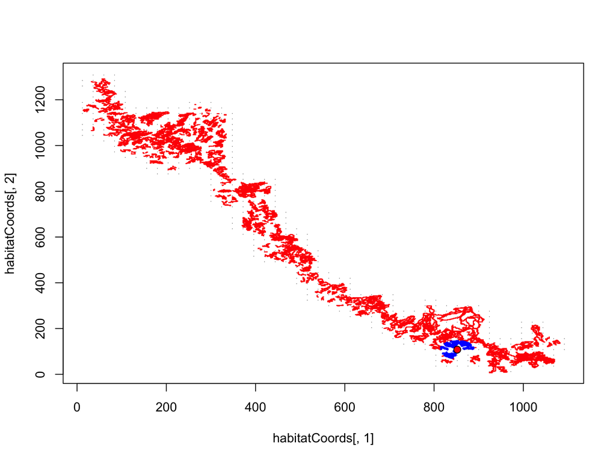

# Explore the data

```r
length(data$z)        # 1 for known individual, NA for data-augmented virtual individual
```

```
## [1] 874
```

```r
sum(data$z == 1, na.rm = TRUE)               # There are 196 known individuals.
```

```
## [1] 196
```

```r
dim(data$detector.xy) # There are 17266 "detectors", which are grid squares with (x, y) coordinates
```

```
## [1] 17266     2
```

```r
dim(data$y)           # There are 874 x 17266 (individual x detector) data points
```

```
## [1]   874 17266
```

```r
sum(data$y==1)        # The vast majority are 0s.  There are 372 detections.
```

```
## [1] 372
```

```r
dim(data$habitat.mx)  # Habitat mask: 1305 x 1089 grid points in a rectangle containing the study area.
```

```
## [1] 1305 1089
```

```r
sum(data$habitat.mx==1)  # 215796 grid squares of valid habitat in the study area with buffer
```

```
## [1] 215796
```

# Four methods to improve efficiency

1. Vectorize computations and use a habitat mask. (Starting point)
2. Jointly (block) sample both coordinates of each activity center. (1.3x)
3. Efficient detection calculations: (40x)
   - Avoid far-away trap calculations: “LESS”.
   - Use sparse data structure for more efficient computation.
4. Skip calculations for virtual individuals when they are not “real”. (2x)
   - Move distance calculations out of model, into custom distribution.
   - For `z[i] == 0` (virtual animal), return answer quickly.

# Original model with “local evaluation” method (Milleret et al. 2018)

- “LESS” = Local Evaluation of the individual State-Space.
- Without this trick, JAGS ran for 30 days, then crashed (on one particular machine).
- This JAGS code was for a simulation study.

```r
sink("SCR-LESS.jags") cat("model {
    ##------------------------------------------------------------
    ##----------    AC PLACEMENT      ---##
    ##-----------------------------------##
    for(i in 1:n.individuals){
    sxy[i,1] ~ dunif(xy.bounds[i,1,1], xy.bounds[i,1,2])
    sxy[i,2] ~ dunif(xy.bounds[i,2,1], xy.bounds[i,2,2])
    pOK[i] <- habitat.mx[trunc(sxy[i,2])+1, trunc(sxy[i,1])+1]
    OK[i] ~ dbern(pOK[i])
    }#i
    ##------------------------------------------------------------
    ##----- DEMOGRAPHIC PROCESS ----##
    ##------------------------------##
    psi0 ~ dunif(0,1)
    psi <- mean(psi1[])
    for (i in 1:n.individuals){
    psi1[i] <- 1-(1-psi0)^prop.habitat[i]
    z[i] ~ dbern(psi1[i])
    }#i
    ##------------------------------------------------------------
    ##---------- DETECTION PROCESS------##
    ##----------------------------------##
    p0 ~ dunif(0,1)
    sigma ~ dunif(0,50)
    alpha <- -1/(2*sigma*sigma)
    #----- DETECTION PROCESS ------#
    for (i in 1:n.individuals){
    for (j in 1:n.detectors[i]){
    d2[i,j] <- pow(sxy[i,1] - detector.xy[detector.index[i,j], 1] ,2) +
               pow(sxy[i,2] - detector.xy[detector.index[i,j], 2], 2)
    p[i,j] <- p0 * exp(alpha * d2[i,j])
    y[i,detector.index[i,j]] ~ dbern(p[i,j]*z[i])
    }#j
    }#i
    ##------------------------------------------------------------
    ##---------- DERIVED PARAMETERS ----------##
    ##----------------------------------------##
    N <- sum(z[])
    }",fill = TRUE)
sink()
```

# Final model in NIMBLE

```r
code <- nimbleCode({
  ## priors
  psi ~ dunif(0, 1)
  sigma ~ dunif(0, 50)
  p0 ~ dunif(0, 1)
  ## loop over individuals
  for(i in 1:n.individuals) {
    ## AC coordinates
    sxy[i,1] ~ dunif(0, x.max)
    sxy[i,2] ~ dunif(0, y.max)
    ## habitat constraint
    ones[i] ~ dHabitatMask( s = sxy[i,1:2],
                            xmin = lowerCoords[1],
                            xmax = upperCoords[1],
                            ymin = lowerCoords[2],
                            ymax = upperCoords[2],
                            habitat = habitat.mx[1:y.max,1:x.max])
    ## latent virtual/real indicators
    z[i] ~ dbern(psi)
    ## likelihood
    y[i, 1:nMaxDetectors] ~ dbinomLocal_normal( detNums = nbDetections[i],
                                                detIndices = yDets[i,1:nMaxDetectors],
                                                size = trials[1:n.detectors],
                                                p0 = p0,
                                                s = sxy[i,1:2],
                                                sigma = sigma,
                                                trapCoords = detector.xy[1:n.detectors,1:2],
                                                localTrapsIndices = detectorIndex[1:n.cells,1:maxNBDets],
                                                localTrapsNum = nDetectors[1:n.cells],
                                                resizeFactor = ResizeFactor,
                                                habitatGrid = habitatIDDet[1:y.maxDet,1:x.maxDet],
                                                indicator = z[i])
  }
  ## derived quantity: total population size
  N <- sum(z[1:n.individuals])
})
```

# nimbleSCR tools to create the inputs: Detectors

```r
DetectorIndex <- getLocalObjects(habitatMask = data$habitat.mx,
                                 coords = data$detector.xy,
                                 dmax = 38,
                                 resizeFactor = 24) # This actually generates the map shown above.

constants$y.maxDet <- dim(DetectorIndex$habitatGrid)[1]   # Coarse grid maximum values
constants$x.maxDet <- dim(DetectorIndex$habitatGrid)[2]
constants$ResizeFactor <- DetectorIndex$resizeFactor      # factor to scale ACs to coarse grid
constants$n.cells <- dim(DetectorIndex$localIndices)[1]
constants$maxNBDets <- DetectorIndex$numLocalIndicesMax   # Max number of local detectors relevant for a coarse grid cell
data$detectorIndex <- DetectorIndex$localIndices          # Detector grid IDs
data$nDetectors <- DetectorIndex$numLocalIndices          # Number of local detectors relevant for each coarse grid cell
data$habitatIDDet <- DetectorIndex$habitatGrid            # Coarse grid IDs
```

# nimbleSCR tools to create the inputs: Detections

Set up sparse version of data:

```r
ySparse <- getSparseY(x = my.jags.input$y)
data$y <- ySparse$y[,,1]                                # Number of detections only where detected
data$yDets <- ySparse$detIndices[,,1]                   # Indices where an animal was detected
data$nbDetections <- ySparse$detNums[,1]                # Number of detectors where an animal was detected
constants$nMaxDetectors <- ySparse$maxDetNums           # Maximum detections for any animal
```

# Look at sparse version of data:

```r
dim(my.jags.input$y) # Size of riginal (dense) version of all detections
```

```
## [1]   874 17266
```

```r
874 * 17266 / (2^20) # megabytes in original version
```

```
## [1] 14.39141
```

```r
dim(data$y)          # Size of sparse version of all detections
```

```
## [1] 874   8
```

```r
874 * 8 / (2^20)     # megabytes in sparse version
```

```
## [1] 0.006668091
```

```r
8 / 17266            # Approx. reduction in iteration/memory work needed to use new version
```

```
## [1] 0.0004633384
```

Iterating over many megabytes of empty information can be inefficient.

# Example of how to use sparse version of data

```r
## Consider animal 1
data$nbDetections[1]  # It was seen at 2 detectors
```

```
## [1] 2
```

```r
data$yDets[1,]        # At detectors 14941 and 14988
```

```
## [1] 14941 14988    -1    -1    -1    -1    -1    -1
```

```r
data$y[1,]            # Once at each detector (this data set has only 1s). "-1"s are fillers: do not use.
```

```
## [1]  1  1 -1 -1 -1 -1 -1 -1
```

```r
constants$nMaxDetectors  # Most detectors where one animal was seen was 8.
```

```
## [1] 8
```

# How detector calculations work with these inputs:

- Activity center –> coarse grid coordinates
- coarse grid coordinates –> coarse grid ID
- coarse grid ID –> relevant detector indices

```r
s <- c(324.6, 736.2)  # Example (x, y) coordinate for an activity center
# Activity center         --> coarse grid coordinates
# ResizeFactor scales from (x, y) to coarse grid
c(trunc(s[2]/constants$ResizeFactor) + 1, trunc(s[1]/constants$ResizeFactor) + 1)
```

```
## [1] 31 14
```

```r
# coarse grid coordinates --> coarse grid ID
data$habitatIDDet[trunc(s[2]/constants$ResizeFactor) + 1, trunc(s[1]/constants$ResizeFactor) + 1]
```

```
## [1] 168
```

```r
dim(data$habitatIDDet)                  # Matrix of coarse grid IDs for each (y,x)
```

```
## [1] 55 46
```

```r
range(data$habitatIDDet)                # Coarse grid IDs range from 0 to 509
```

```
## [1]   0 509
```

```r
# coarse grid ID          --> relevant detector indices (on detector grid, not coarse grid)
data$detectorIndex[168, 1:data$nDetectors[168] ] # The rest are zeros
```

```
##  [1] 9745 9746 9757 9758 9759 9760 9761 9762 9763 9774 9775 9776 9777 9778 9782
## [16] 9783 9797 9798 9808 9809 9810 9811 9819 9820 9821 9822 9823 9824 9837 9838
## [31] 9839 9840 9841 9842 9843 9854 9855 9856 9857 9858 9859 9860 9861 9871 9872
## [46] 9873 9901 9902 9908 9909 9910 9911 9912 9918 9919 9920
```

```r
dim(data$detectorIndex)
```

```
## [1] 509 679
```

# Summary of detector and detection calculations with the sparse inputs:

- Activity center –> relevant detector indices
- Detection data –> where non-zero detections occurred
- Detection data –> zero detections everywhere else

# How habitat mask calculations work with these inputs:

```r
with(constants, c(x.max, y.max)) # Be careful about (x, y) vs. (y, x)
```

```
## [1] 1089 1305
```

```r
s <- c(324.6, 736.2)             # Example (x, y) coordinate for an activity center
dim(data$habitat.mx)             # Habitat mask
```

```
## [1] 1305 1089
```

```r
data$habitat.mx[707, 416]        # How to look up whether an AC is in valid habitat, set up as (y, x)
```

```
## [1] 1
```

```r
data$habitat.mx[trunc(s[2]) + 1, trunc(s[1]) + 1] # How to do it from x = s[1], y = s[2]
```

```
## [1] 1
```

# Writing the `dbinomLocal_normal` `nimbleFunction` for efficient detection calculations:

```r
dbinomLocal_normal # You can look at source code like any R function...
```

```r
# ... but let's look at original source code with type declarations and comments
dbinomLocal_normal <- nimbleFunction(
  run = function( x = double(1),
                  detNums = double(0, default = -999),
                  detIndices = double(1),
                  size = double(1),
                  p0 = double(0, default = -999),
                  p0Traps = double(1),
                  sigma = double(0),
                  s = double(1),
                  trapCoords = double(2),
                  localTrapsIndices = double(2),
                  localTrapsNum = double(1),
                  resizeFactor = double(0, default = 1),
                  habitatGrid = double(2),
                  indicator = double(0),
                  lengthYCombined = double(0, default = 0),
                  log = integer(0, default = 0)
  ) {
    ## Specify return type
    returnType(double(0))

    ## Deal with cases where detection info is combined in one vector
    if(detNums==-999){
      detNums <- x[1]
      nMaxDetectors <- (lengthYCombined-1)/2
      detIndices1 <- x[(nMaxDetectors+2):lengthYCombined]
      x1 <- x[2:(nMaxDetectors+1)]
    }else{
      x1 <- x
      detIndices1 <- detIndices
    }

    ## Shortcut if the current individual is not available for detection
    if(indicator == 0){
      if(detNums == 0){
        if(log == 0) return(1.0)
        else return(0.0)
      } else {
        if(log == 0) return(0.0)
        else return(-Inf)
      }
    }

    ## Retrieve the index of the habitat cell where the current AC is
    sID <- habitatGrid[trunc(s[2]/resizeFactor)+1, trunc(s[1]/resizeFactor)+1]

    ## Retrieve the indices of the local traps surrounding the selected habita grid cell
    theseLocalTraps <- localTrapsIndices[sID,1:localTrapsNum[sID]]

    ## CHECK IF DETECTIONS ARE WITHIN THE LIST OF  LOCAL TRAPS
    if(detNums > 0){
      for(r in 1:detNums){
        if(sum(detIndices1[r] == theseLocalTraps) == 0){
          if(log == 0) return(0.0)
          else return(-Inf)
        }
      }
    }

    ## Calculate the log-probability of the vector of detections
    alpha <- -1.0 / (2.0 * sigma * sigma)
    logProb <- 0.0
    detIndices1 <- c(detIndices1, 0)
    count <- 1


    if(p0==-999){# when p0 is provide through p0Traps
      for(r in 1:localTrapsNum[sID]){
        if(theseLocalTraps[r] == detIndices1[count]){
          d2 <- pow(trapCoords[theseLocalTraps[r],1] - s[1], 2) + pow(trapCoords[theseLocalTraps[r],2] - s[2], 2)
          p <- p0Traps[theseLocalTraps[r]] * exp(alpha * d2)
          logProb <-  logProb + dbinom(x1[count], prob = p, size = size[theseLocalTraps[r]], log = TRUE)
          count <- count + 1
        }else{
          d2 <- pow(trapCoords[theseLocalTraps[r],1] - s[1], 2) + pow(trapCoords[theseLocalTraps[r],2] - s[2], 2)
          p <- p0Traps[theseLocalTraps[r]] * exp(alpha * d2)
          logProb <- logProb + dbinom(0, prob = p, size = size[theseLocalTraps[r]], log = TRUE)

        }
      }
    }else{# when p0 is provide through p0
      for(r in 1:localTrapsNum[sID]){
        if(theseLocalTraps[r] == detIndices1[count]){
          d2 <- pow(trapCoords[theseLocalTraps[r],1] - s[1], 2) + pow(trapCoords[theseLocalTraps[r],2] - s[2], 2)
          p <- p0 * exp(alpha * d2)
          logProb <-  logProb + dbinom(x1[count], prob = p, size = size[theseLocalTraps[r]], log = TRUE)
          count <- count + 1
        }else{
          d2 <- pow(trapCoords[theseLocalTraps[r],1] - s[1], 2) + pow(trapCoords[theseLocalTraps[r],2] - s[2], 2)
          p <- p0 * exp(alpha * d2)
          logProb <- logProb + dbinom(0, prob = p, size = size[theseLocalTraps[r]], log = TRUE)
        }
      }
    }


    ## Return the probability of the vector of detections (or log-probability if required)
    if(log)return(logProb)
    return(exp(logProb))
  })
```

# Run the case study

```r
Rmodel <- nimbleModel(code, constants, data, inits)
```

```r
conf <- configureMCMC(Rmodel, monitors = c("N", "sigma", "p0"), print = FALSE)
conf$removeSamplers("sxy")
ACnodes <- paste0("sxy[", 1:constants$n.individuals, ", 1:2]")
for(node in ACnodes) {
  conf$addSampler(target = node,
                  type = "RW_block",
                  control = list(adaptScaleOnly = TRUE),
                  silent = TRUE)
}
Rmcmc <- buildMCMC(conf)
```

```r
Cmodel <- compileNimble(Rmodel)
Cmcmc <- compileNimble(Rmcmc, project = Rmodel)
MCMC_runtime <- system.time(
  samples <- runMCMC(Cmcmc, niter = 2000, samplesAsCodaMCMC = TRUE)
)
```

# Look at results

```r
colnames(samples)
```

```
## [1] "N"     "p0"    "sigma"
```

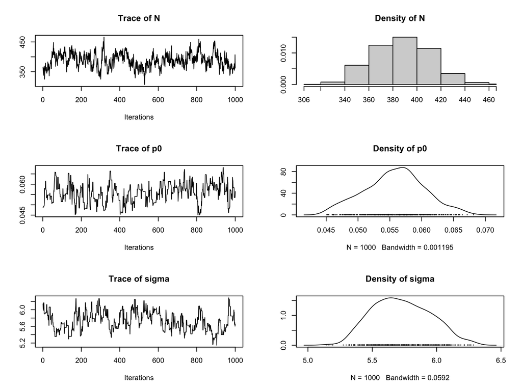

```r
plot(coda::as.mcmc(samples[1001:2000,]))
```